# Multi-agency partnership research project

IASC report

July 2017

This document contains all figures for the *IASC report*. To look at each figure individually, please got to folder write_ups/figures.

### Data

The table below reports the ‘as is’ data before any data manipulations.

| PartnershipID | RespondantID | GapIDs | ChallengeIDs | EffectiveIDs | PoliceIDs | MemberIDs | National | Regional | SubregionalCB | SubregionalForce | Local | Neighbourhood | NoPartnership | ChairID | Chairscore | CordinatorID | Coordscore | GovID | Govscore | Frequency ID | Freqscore | Actionscore | Community | Frontline | Intel | Enforcement | Commissioning | Supply | Referrals | … |
| --- | --- | --- | --- | --- | --- | --- | --- | --- | --- | --- | --- | --- | --- | --- | --- | --- | --- | --- | --- | --- | --- | --- | --- | --- | --- | --- | --- | --- | --- | --- |
| 1 | Police | INFO-SHARING, STRATEGIC COORDINATION | FUNDING, VICTIMS, COORDINATION, CONFLICTS, ENGAGEMENT | INFO SHARING, REGIONAL FACILITIES | cheshire | LA (TT), NCA, GLAA, HMRC, NGO, FBO, CPS, FIRE, DWP, ROCU, NHS, IMMIGRATION |  |  |  | Y |  |  |  | INDEPENDENT | -1 | INDEPENDENT | -1 | Y | 1 | Q | 0 | 1 | y |  | y | y | y |  |  | … |
| 2 | Police | INFO-SHARING, STRATEGIC COORDINATION | FUNDING, VICTIMS, COORDINATION, CONFLICTS, ENGAGEMENT | INFO SHARING, REGIONAL FACILITIES | cheshire | ADULTS / CHILDRENS SAFEGUARDING, LA (TT), POLICE, NHS, |  |  |  |  | Y |  |  | LA (TT) | 1 | LA (TT) | 1 | Y | 1 | Q | 0 | -1 | y | y | y | y | y | y | y | … |
| 3 | Police |  | FUNDING | FUNDING | lancashire | UNIVERSITY, FBO, NGO |  |  |  | Y |  |  |  | POLICE | 1 | POLICE | 1 | N | -1 | TBD | 0 | -1 | y | y | y | y |  |  |  | … |
| 4 | Police, NGO, LA (TT) | NO GAPS, VICTIMS | DATA, COORDINATION | GUIDANCE | dorset | LA (TT), NHS, HMRC, ROCU, NGO, SAFEGUARDING, ROCU, IMMIGRATION, GAIN, HOUSING |  |  |  | Y |  |  |  | POLICE | 1 | POLICE | 1 | Y | 1 | Q | 0 | 1 | y | y | y | y |  |  | y | … |
| 5 | Police | VICTIMS, FUNDING, STRATEGIC COORDINATION | FUNDING, CONFLICTS | FUNDING, COORDINATION | derbyshire | LA (TT), GLAA, UNIVERSITY, NGO, FBO, FIRE |  |  |  | Y |  |  |  | LA (TT) | 1 | LA (TT) | 1 | N | -1 | A/R | 1 | 1 | y | y | y | y | y |  | y | … |
| 6 | Police | ENGAGEMENT | DATA, AWARENESS | COORDINATION | cumbria |  |  |  |  |  |  |  | Y | N/A |  | N/A |  | N | -1 | N/A |  |  |  |  |  |  |  |  |  | … |
| 7 | Police | STRATEGIC COORDINATION | CONFLICTS, COORDINATION, OWNERSHIP | RESOLVE CONFLICTS, GUIDANCE | hampshire | IMMIGRATION, NGO, LA (TT), UKBA, GLAA, FBO, HMRC, FIRE, NHS |  |  |  | Y |  |  |  | OPCC | 1 | OPCC | 1 | Y | 1 | A/R | 1 | -1 | y | y | y | y | y |  |  | … |
| 8 | Police | STRATEGIC COORDINATION, ENGAGEMENT | AWARENESS, DATA, OWNERSHIP, COORDINATION, CONFLICTS | COORDINATION |  | GLAA, IMMIGRATION, LA (TT), NCA, NHS, GAIN, DWP, HMRC, FIRE, POLICE |  |  |  | Y |  |  |  | POLICE | 1 | POLICE | 1 | Y | 1 | M | 1 | -1 | y | y | y | y |  |  | y | … |
| 9 | Police |  | ENGAGEMENT |  | cityoflondon |  |  |  |  |  |  |  | Y | N/A |  | N/A |  | N | -1 | N/A |  |  |  |  |  |  |  |  |  | … |
| 10 | Police | STRATEGIC COORDINATION, ENGAGEMENT | ENGAGEMENT, CONFLICTS | GUIDANCE, ACCOUNTABILITY | staffordshire | HOUSING, NHS, CRIMESTOPPERS, DWP, LA (TT), LA (2T), GLAA, HMRC, IMMIGRATION, NCA, OPCC, NGO, ADULTS / CHILDRENS SAFEGUARDING, FIRE, POLICE, ROCU |  |  |  | Y |  |  |  | OPCC | 1 | LA (TT) | 1 | Y | 1 | Q | 0 | 1 | y | y | y | y | y |  | y | … |

[output cut: 77 more lines]

### Figures

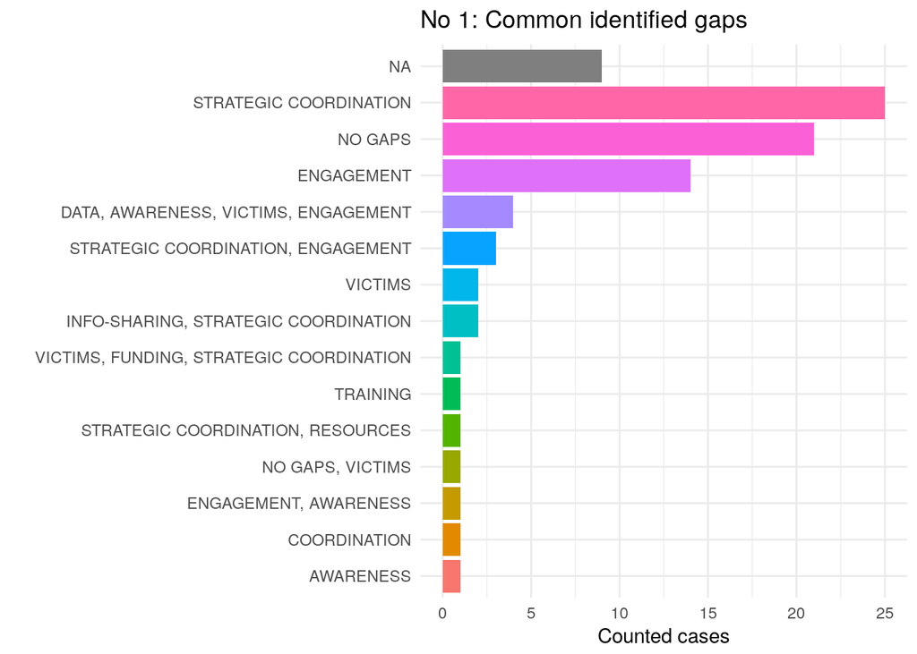

Working with the data and building the first graph(s) a few things came to my mind

1. Obs 78 is missing a lot of data. Generally, are we going to keep/drop all missing observations for each category?
2. Is ‘no gaps’ a regular category or more like the *NA*s?
3. Is there a preferred way of visualising the results, that is bar charts, pie charts etc.? Also, are there any corporate design elements I should keep in mind (colour coding, fonts etc.)
4. Do you prefer png or PDF versions of the graphs?
5. The above figure uses capital letters only because this is how the data was initially coded up. I can change this if desired.
6. In the above figure some categories seem to overlap, e.g. ‘engagement’ vs. ‘data, awareness, victims, engagement’. Is this OK or should each group count towards its components separately? I think for the ‘common challenges’ the graph in the above design would be very difficult to read:

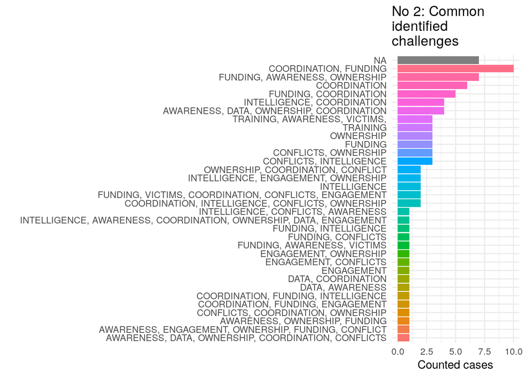

The alternative version would produce something like this:

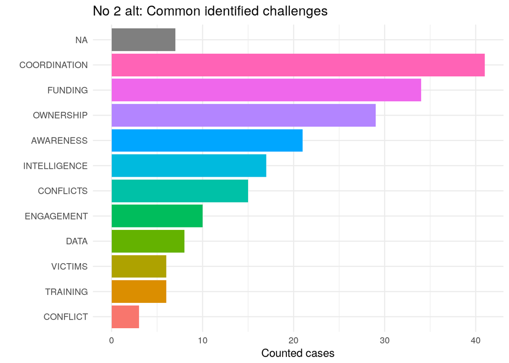

In order to go ahead with this, it would be useful to know if you want to keep all missing responses (the *NA*s) for either the report/writing and/or the final report. I am happy to change this any time.